# Practicum 1 - birds

# Parts 1-3

```sql
set global local_infile=true;
```

Step 1: Create a new database and connect to it.

```sql
CREATE DATABASE IF NOT EXISTS bird;
```

Seeing if it worked:

```sql
SHOW DATABASES;
```

| Database |
| --- |
| bird |
| information_schema |
| mysql |
| performance_schema |
| sys |

We see that “bird” was created, the name of our DB.

Step 2: Create the 3 tables. The instructions say to use default values where the data file does not contain values or leave empty, unless it is airport or airline (add unknown as the default rather than null, n/a, or empty). For the airport table, aid is a synthetic primary key so we can use AUTO_INCREMENT.

```sql
CREATE TABLE airports(
  aid INTEGER NOT NULL AUTO_INCREMENT,
  airportName VARCHAR(255) DEFAULT 'unknown',
  airportCode VARCHAR(3) DEFAULT null,
  state TEXT,

  PRIMARY KEY (aid)
);
```

Since this is a look-up table, we can also use AUTO_INCREMENT for the PK.

```sql
CREATE TABLE conditions(
  cid INTEGER NOT NULL AUTO_INCREMENT,
  `condition` TEXT,
  explanation TEXT DEFAULT null,

  PRIMARY KEY (cid)
);
```

This table needs to have appropriate FKs to connect to the PKs of the previous two tables. Origin and conditions will be the PKs of those tables.

```sql
CREATE TABLE incidents(
  rid INTEGER NOT NULL,
  date DATE,
  origin INTEGER,
  airline VARCHAR(255) DEFAULT 'unknown',
  aircraft TEXT,
  flightPhase TEXT,
  altitude INTEGER,
  conditions INTEGER,
  warning BIT DEFAULT b'0',

  FOREIGN KEY (origin) REFERENCES airports(aid),
  FOREIGN KEY (conditions) REFERENCES conditions(cid),
  PRIMARY KEY (rid)
);
```

Check to make sure the tables were created:

```sql
SHOW TABLES;
```

| Tables_in_bird |
| --- |
| airports |
| conditions |
| incidents |

Step 3: Load data.

```r
fn = "BirdStrikesData.csv"

df.raw <- read.csv(file = fn,
                   header = T,
                   stringsAsFactors = F)
# set backing store to SQLite for sqldf
options(sqldf.driver = 'SQLite')
```

Directly making this modification (airport or airline - add unknown as the default rather than null, n/a, or empty) to the raw df, so I can use this information correctly when setting up the FKs later.

```r
# Search for empty or null values in the "airport" column and replace with "unknown"
df.raw$airport <- ifelse(is.na(df.raw$airport) | df.raw$airport == "", "unknown", df.raw$airport)

# Search for empty or null values in the "airline" column and replace with "unknown"
df.raw$airline <- ifelse(is.na(df.raw$airline) | df.raw$airline == "", "unknown", df.raw$airline)
```

Creating DF for the airports table:

```r
# select a fixed value for the first column, it acts as a placeholder for the artificial PK
df.airports <- sqldf::sqldf("select 1 as aid, airport, origin from `df.raw` group by airport, origin")

# assign an artificial PK using a counter
n.airports <- nrow(df.airports)
df.airports[,1] <- seq(1, n.airports)

# change df names to the DB ones
names(df.airports) <- c("aid", "airportName", "state")

# adding airportcode placeholder column
df.airports$airportCode <- NA
df.airports <- df.airports[, c("aid", "airportName", "airportCode", "state")]
```

Checking to make sure the DF matches the airport table:

```r
df.airports
```

| aid | airportName | airportCode | state |
| --- | --- | --- | --- |
| 1 | ABERDEEN REGIONAL AR | NA | South Dakota |
| 2 | ABILENE REGIONAL ARPT | NA | Texas |
| 3 | ABRAHAM LINCOLN CAPITAL ARPT | NA | Illinois |
| 4 | ADAMS COUNTY- LEGION FIELD | NA | Wisconsin |
| 5 | ADAMS FIELD ARPT | NA | Arkansas |
| 6 | ADDINGTON FIELD ARPT | NA | Kentucky |
| 7 | ADDISON | NA | Texas |
| 8 | ADIRONDAK REGIONAL ARPT | NA | New York |
| 9 | AIRBORNE AIRPARK | NA | Ohio |
| 10 | AKRON-CANTON MUNICIPAL | NA | Ohio |

[output cut: 990 more lines]

```r
NA
```

We have a synthetic PK, airports grouped by their name and location (which is relevant for the unknowns (as they come from different states)), and the empty airportCode col.

```r
# filter the dataframe by unknown
filtered_df <- subset(df.airports, airportName == "unknown")

# view the filtered dataframe
filtered_df
```

|  | aid | airportName | airportCode | state |
| --- | --- | --- | --- | --- |
| 1110 | 1110 | unknown | NA | Alabama |
| 1111 | 1111 | unknown | NA | Alaska |
| 1112 | 1112 | unknown | NA | Arizona |
| 1113 | 1113 | unknown | NA | Arkansas |
| 1114 | 1114 | unknown | NA | California |
| 1115 | 1115 | unknown | NA | Florida |
| 1116 | 1116 | unknown | NA | Georgia |
| 1117 | 1117 | unknown | NA | Hawaii |
| 1118 | 1118 | unknown | NA | Illinois |
| 1119 | 1119 | unknown | NA | Indiana |

[output cut: 22 more lines]

```r
NA
```

Theoretically even though the airport name is unknown we can still retain the state information for the origin for these planes.

Load data:

```r
dbWriteTable(mydb, "airports", df.airports, overwrite = F, append = T,
row.names = FALSE, field.types = c(aid = "integer", airportName = "text", airportCode = "varchar(3)", state = "TEXT"))
```

```
[1] TRUE
```

Checking to see the data loaded in.

```sql
SELECT * FROM airports LIMIT 50;
```

| aid | airportName | airportCode | state |
| --- | --- | --- | --- |
| 1 | ABERDEEN REGIONAL AR | NA | South Dakota |
| 2 | ABILENE REGIONAL ARPT | NA | Texas |
| 3 | ABRAHAM LINCOLN CAPITAL ARPT | NA | Illinois |
| 4 | ADAMS COUNTY- LEGION FIELD | NA | Wisconsin |
| 5 | ADAMS FIELD ARPT | NA | Arkansas |
| 6 | ADDINGTON FIELD ARPT | NA | Kentucky |
| 7 | ADDISON | NA | Texas |
| 8 | ADIRONDAK REGIONAL ARPT | NA | New York |
| 9 | AIRBORNE AIRPARK | NA | Ohio |
| 10 | AKRON-CANTON MUNICIPAL | NA | Ohio |

[output cut: 40 more lines]

Checking to make sure the unknowns retained the state differences

```sql
SELECT * FROM airports WHERE airportName='unknown';
```

| aid | airportName | airportCode | state |
| --- | --- | --- | --- |
| 1110 | unknown | NA | Alabama |
| 1111 | unknown | NA | Alaska |
| 1112 | unknown | NA | Arizona |
| 1113 | unknown | NA | Arkansas |
| 1114 | unknown | NA | California |
| 1115 | unknown | NA | Florida |
| 1116 | unknown | NA | Georgia |
| 1117 | unknown | NA | Hawaii |
| 1118 | unknown | NA | Illinois |
| 1119 | unknown | NA | Indiana |

[output cut: 22 more lines]

Creating DF for the conditions table:

```r
# select a fixed value for the first column, it acts as a placeholder for the artificial PK
df.conditions<- sqldf::sqldf("select 1 as cid, sky_conditions from `df.raw` group by sky_conditions")

# assign an artificial PK using a counter
n.conditions <- nrow(df.conditions)
df.conditions[,1] <- seq(1, n.conditions)

# change df names to the DB ones
names(df.conditions) <- c("cid", "condition")

# adding explanation placeholder column
df.conditions$explanation <- NA
```

Checking to make sure the DF matches the conditions table:

```r
df.conditions
```

| cid | condition | explanation |
| --- | --- | --- |
| 1 | No Cloud | NA |
| 2 | Overcast | NA |
| 3 | Some Cloud | NA |

```r
NA
```

Load data:

```r
dbWriteTable(mydb, "conditions", df.conditions, overwrite = F, append = T,
row.names = FALSE, field.types = c(cid = "integer", condition = "text", explanation = "text"))
```

```
[1] TRUE
```

Checking to see the data loaded in (there should be only 3 but I am using LIMIT 5 to make sure).

```sql
SELECT * FROM conditions LIMIT 5;
```

| cid | condition | explanation |
| --- | --- | --- |
| 1 | No Cloud | NA |
| 2 | Overcast | NA |
| 3 | Some Cloud | NA |

Creating DF for the incidents table:

```r
# select a fixed value for the origin and conditions, it acts as a placeholder for the FKs
n.incidents <- nrow(df.raw)
df.incidents <- data.frame(rid = df.raw$rid,
                           date = df.raw$flight_date,
                           origin = 1,
                           airline = df.raw$airline,
                           aircraft = df.raw$aircraft,
                           flightPhase = df.raw$flight_phase,
                           altitude = df.raw$altitude_ft,
                           conditions = 1,
                           warning = df.raw$pilot_warned_flag
)

# changing T to TRUE and F to FALSE in warning column
df.incidents$warning <- ifelse(df.incidents$warning == "T", TRUE, FALSE)
# changing altitude column to int
df.incidents$altitude <- as.integer(gsub(",", "", df.incidents$altitude))
# reformatting date column
df.incidents$date <- as.Date(df.incidents$date, format = "%m/%d/%Y %H:%M")
df.incidents$date <- format(df.incidents$date, "%Y-%m-%d")
#changing dbl to int
df.incidents$origin <- as.integer(df.incidents$origin)
df.incidents$conditions <- as.integer(df.incidents$conditions)
```

Checking to make sure the DF matches the incidents table (and all of the required modifications went in):

```r
df.incidents
```

| rid | date | origin | airline | aircraft | flightPhase | altitude | conditions | warning |
| --- | --- | --- | --- | --- | --- | --- | --- | --- |
| 202152 | 2000-11-23 | 1 | US AIRWAYS* | Airplane | Climb | 1500 | 1 | FALSE |
| 208159 | 2001-07-25 | 1 | AMERICAN AIRLINES | Airplane | Landing Roll | 0 | 1 | FALSE |
| 207601 | 2001-09-14 | 1 | BUSINESS | Airplane | Approach | 50 | 1 | FALSE |
| 215953 | 2002-09-05 | 1 | ALASKA AIRLINES | Airplane | Climb | 50 | 1 | FALSE |
| 219878 | 2003-06-23 | 1 | COMAIR AIRLINES | Airplane | Approach | 50 | 1 | FALSE |
| 218432 | 2003-07-24 | 1 | AMERICAN AIRLINES | Airplane | Take-off run | 0 | 1 | FALSE |
| 221697 | 2003-08-17 | 1 | BUSINESS | Airplane | Climb | 150 | 1 | FALSE |
| 236635 | 2006-03-01 | 1 | UNITED AIRLINES | Airplane | Approach | 100 | 1 | FALSE |
| 207369 | 2000-01-06 | 1 | AIRTRAN AIRWAYS | Airplane | Take-off run | 0 | 1 | FALSE |
| 204371 | 2000-01-07 | 1 | AIRTOURS INTL | Airplane | Landing Roll | 0 | 1 | FALSE |

[output cut: 990 more lines]

```r
NA
```

We see that DATE is now in the correct DATE format, the TRUE and FALSE tags are updated correctly, and the data types are appropriate.

Now we need to update our placeholder FK cols:

```r
# updating placeholder FK columns with the correct PKs from our previous tables
# process each row (incidents) one by one
for (r in 1:n.incidents) {
  # find the airport PK for that incident in the airport table
  a <- df.airports$aid[which(df.airports$airportName == df.raw$airport[r] &
                               df.airports$state == df.raw$origin[r])]

  df.incidents$origin[r] <- a
}
```

```r
# updading our placeholder FK columns with the correct info from our previous tables
# process each row (incidents) one by one
for (r in 1:n.incidents) {
  # find the conditions PK for that incident in the conditions table
  a <- df.conditions$cid[which(df.conditions$condition == df.raw$sky_conditions[r])]

  df.incidents$conditions[r] <- a
}
```

Load data:

```r
dbWriteTable(mydb, "incidents", df.incidents, overwrite = F, append = T,
row.names = FALSE, field.types = c(
  rid = "integer",
  date = "date",
  origin = "integer",
  airline = "VARCHAR(255)",
  aircraft = "text",
  flightPhase = "text",
  altitude = "integer",
  conditions = "integer",
  warning = "bit",))
```

```
[1] TRUE
```

Checking to see the data loaded in:

```sql
SELECT * FROM incidents LIMIT 50;
```

| rid | date | origin | airline | aircraft | flightPhase | altitude | conditions | warning |
| --- | --- | --- | --- | --- | --- | --- | --- | --- |
| 1195 | 2002-11-13 | 57 | MILITARY | Airplane | Approach | 2000 | 2 | 0 |
| 3019 | 2002-10-10 | 264 | MILITARY | Airplane | Climb | 400 | 1 | 0 |
| 3500 | 2001-05-15 | 57 | MILITARY | Airplane | Approach | 1000 | 1 | 0 |
| 3504 | 2001-05-23 | 57 | MILITARY | Airplane | Approach | 1800 | 1 | 0 |
| 3597 | 2001-04-18 | 920 | MILITARY | Airplane | Approach | 200 | 3 | 0 |
| 4064 | 2000-04-06 | 57 | MILITARY | Airplane | Approach | 1000 | 1 | 0 |
| 4074 | 2002-07-15 | 265 | MILITARY | Airplane | Take-off run | 0 | 1 | 0 |
| 4076 | 2002-07-15 | 57 | MILITARY | Airplane | Climb | 500 | 3 | 0 |
| 4090 | 2001-07-02 | 143 | MILITARY | Airplane | Climb | 50 | 3 | 0 |
| 4091 | 2001-07-07 | 143 | MILITARY | Airplane | Take-off run | 0 | 3 | 0 |

[output cut: 40 more lines]

Checking to make sure all the rows went in (should be 25558)

```sql
SELECT count(*) FROM incidents;
```

| count(*) |
| --- |
| 25558 |

Step 4: Update data in the DB to meet harmonize and military flights requirements. First, remove military flights:

```sql
DELETE FROM incidents
WHERE airline = 'MILITARY';
```

Checking to confirm:

```sql
SELECT * FROM incidents WHERE airline = 'MILITARY';
```

| rid | date | origin | airline | aircraft | flightPhase | altitude | conditions | warning |
| --- | --- | --- | --- | --- | --- | --- | --- | --- |

It is probably not needed to keep the military airline in the airports table:

```sql
DELETE FROM airports
WHERE airportName = 'MILITARY';
```

Checking to confirm:

```sql
SELECT * FROM airports WHERE airportName = 'MILITARY';
```

| aid | airportName | airportCode | state |
| --- | --- | --- | --- |

Checking data one more time:

```sql
SELECT * FROM incidents LIMIT 50;
```

| rid | date | origin | airline | aircraft | flightPhase | altitude | conditions | warning |
| --- | --- | --- | --- | --- | --- | --- | --- | --- |
| 200011 | 2000-04-06 | 803 | ABX AIR | Airplane | Landing Roll | 0 | 2 | 0 |
| 200012 | 2000-04-10 | 279 | AIR MIDWEST | Airplane | Landing Roll | 0 | 2 | 0 |
| 200022 | 2000-02-28 | 209 | AMERICAN EAGLE AIRLINES | Airplane | Approach | 2000 | 1 | 0 |
| 200023 | 2000-08-25 | 778 | US AIRWAYS* | Airplane | Descent | 7000 | 1 | 0 |
| 200028 | 2000-03-22 | 234 | UNITED AIRLINES | Airplane | Approach | 3000 | 1 | 0 |
| 200029 | 2000-05-14 | 571 | BUSINESS EXPRESS | Airplane | Approach | 30 | 1 | 0 |
| 200031 | 2000-06-12 | 233 | GREAT LAKES AIRLINES | Airplane | Approach | 500 | 1 | 0 |
| 200036 | 2000-09-29 | 716 | BUSINESS | Airplane | Climb | 1000 | 1 | 0 |
| 200037 | 2001-02-01 | 887 | UNITED AIRLINES | Airplane | Take-off run | 0 | 3 | 0 |
| 200042 | 2000-08-31 | 990 | FEDEX EXPRESS | Airplane | Approach | 400 | 3 | 0 |

[output cut: 40 more lines]

Next, lets harmonize. Assumptions: climb, Take-off run, and takeoff are all called takeoff approach, Landing Roll, and landing are all called landing inflight and descent is called inflight taxi and parked and blank are called unknown.

```sql
UPDATE incidents
SET flightPhase =
    CASE
        WHEN LOWER(flightPhase) LIKE '%takeoff%' OR
        LOWER(flightPhase) = 'climb' OR
        LOWER(flightPhase) = 'take-off run'
        THEN 'takeoff'

        WHEN LOWER(flightPhase) LIKE '%landing%' OR
        LOWER(flightPhase) = 'approach' OR
        LOWER(flightPhase) = 'landing roll'
        THEN 'landing'

        WHEN LOWER(flightPhase) LIKE '%inflight%' OR
        LOWER(flightPhase) = 'descent'
        THEN 'inflight'

        ELSE 'unknown'
    END;
```

Checking to make sure everything got coded as landing, takeoff, inflight, or unknown

```sql
SELECT DISTINCT flightPhase FROM incidents;
```

| flightPhase |
| --- |
| landing |
| inflight |
| takeoff |
| unknown |

# Part 4

Find the top-10 airlines with the most number of incidents

```sql
SELECT airline, COUNT(*) as num_incidents FROM incidents
GROUP BY airline
ORDER BY num_incidents DESC
LIMIT 10;
```

| airline | num_incidents |
| --- | --- |
| SOUTHWEST AIRLINES | 4628 |
| BUSINESS | 3074 |
| AMERICAN AIRLINES | 2058 |
| DELTA AIR LINES | 1349 |
| AMERICAN EAGLE AIRLINES | 932 |
| SKYWEST AIRLINES | 891 |
| US AIRWAYS* | 797 |
| JETBLUE AIRWAYS | 708 |
| UPS AIRLINES | 590 |
| US AIRWAYS | 540 |

# Part 5

Find the flight phase that had an above average number bird strike incidents (during any flight phase).

```sql
# Takes the rows in flightPhase and counts them (saves as num_incidents)
# The OVER() is used with AVG() to preform the avg over a set of rows that is different from the rows being returned by the query, meaning it is the average of the all the incidents regardless of phase (when we are grouping by phase later on) (saves as avg_num_incidents)
# Then we just have to compare num_incidents with the overal avg to find out which flight phases have more strikes than avg.

SELECT flightPhase, num_incidents, avg_num_incidents
FROM (
  SELECT flightPhase, COUNT(*) as num_incidents, AVG(COUNT(*)) OVER() as avg_num_incidents
  FROM incidents
  GROUP BY flightPhase
) subq
WHERE num_incidents > avg_num_incidents;
```

| flightPhase | num_incidents | avg_num_incidents |
| --- | --- | --- |
| landing | 15390 | 6367.25 |
| takeoff | 9091 | 6367.25 |

# Part 6

Create a SQL query against your database to find the maximum number of bird strike incidents by month (across all years). Include all airlines and all flights. Some of the date information is missing, and by defualt the query will ignore those rows.

```sql
#outer q groups the rows by month and calculates the total number of bird strike incidents
#sub q recalculates that same information, selects the max
#then the outer q is filtered using having, showing the rows where total_incidents is the max

SELECT MONTH(date) AS month, COUNT(*) AS total_incidents
FROM incidents
GROUP BY MONTH(date)
HAVING total_incidents = (
  SELECT MAX(total_incidents)
  FROM (
    SELECT COUNT(*) AS total_incidents
    FROM incidents
    GROUP BY MONTH(date)
  ) subq
);
```

| month | total_incidents |
| --- | --- |
| 8 | 3704 |

# Part 7

Build a column chart that visualizes the number of bird strikes incidents per year from 2005 to 2011.

Creating the DF

```r
# construct a SQL query
sqlCmd = "SELECT YEAR(date) AS year, COUNT(*) AS num_incidents
FROM incidents
WHERE YEAR(date) BETWEEN 2005 AND 2011
GROUP BY YEAR(date)
ORDER BY YEAR(date) ASC;"

# send the SQL query to the database
strike = dbGetQuery(mydb, sqlCmd)

#checking the df to see if it worked
strike
```

| year | num_incidents |
| --- | --- |
| 2005 | 1853 |
| 2006 | 2159 |
| 2007 | 2301 |
| 2008 | 2258 |
| 2009 | 3247 |
| 2010 | 3121 |
| 2011 | 2952 |

```r
NA
```

Making the chart

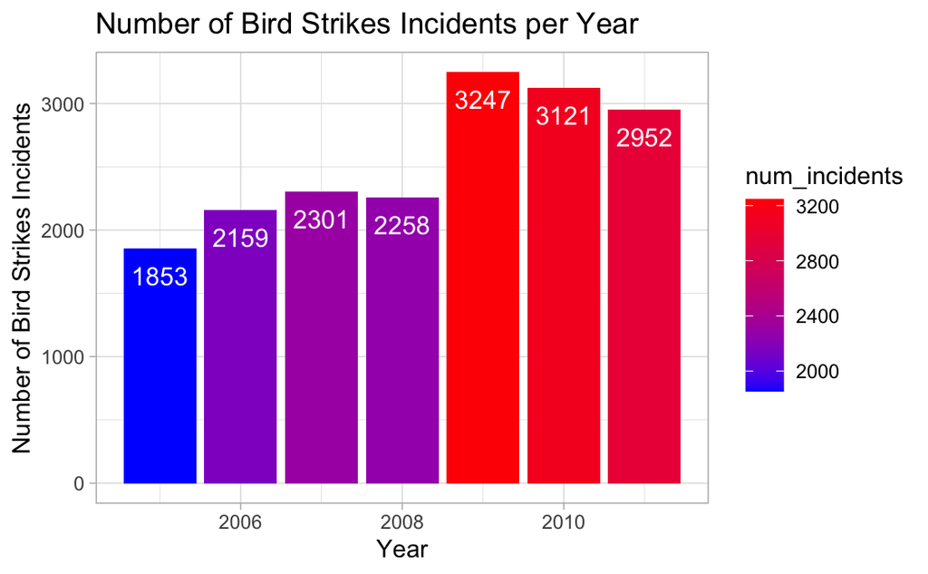

```r
library(ggplot2)

# create chart
strikeplot <- ggplot(strike, aes(x=year, y=num_incidents, fill=num_incidents)) +
  geom_col() +
  scale_fill_gradient(low="blue", high="red") +
  ggtitle("Number of Bird Strikes Incidents per Year") +
  xlab("Year") +
  ylab("Number of Bird Strikes Incidents") +
  theme_light() +
  geom_text(aes(label=num_incidents), vjust=2, color="white", size=4)

strikeplot
```

# Part 8

Create a stored procedure in MySQL that adds a new incident to the database

This stored procedure to add a new incident to the database first declares two new variables, airport_count and new_aid. These are both used to determine if a new airport needs to be added to the airport table (and to record the aid for the incidents table).

The next part counts the number of rows, and stores it in airport_count where the airportName = the airport parameter. If airport_count = 0, then we know that the airport doesn’t exist, so we add it. We also set the new aid from that addition to the new_aid variable. Even if we didn’t have to add a new airport, we still want to record the aid in the new_aid variable so we can use it in the next part.

Next, we move on to the insert statement for the incidents table. This part simply assigns the parameters to the correct values, and uses the new_aid for the origin FK as explained above.

This stored procedure adds a bird strike incident and accounts for there being potentially a new airport. It does not account for there being a new condition as that was not mentioned in the assignment, so for the p_condition parameter you would enter 1, 2, or 3.

```sql
CREATE PROCEDURE add_incident(
IN p_airport VARCHAR(255),
IN p_state TEXT,
IN p_rid INT,
IN p_date DATE,
IN p_airline VARCHAR(255),
IN p_aircraft TEXT,
IN p_flightPhase TEXT,
IN p_altitude INT,
IN p_condition INT,
IN p_warning BIT
)

BEGIN
    DECLARE airport_count INT;
    DECLARE new_aid INT;

    SELECT COUNT(*) INTO airport_count
    FROM airports
    WHERE airportName = p_airport;

    IF airport_count = 0 THEN
        INSERT INTO airports (airportName, state)
        VALUES (p_airport, p_state);
        SET new_aid = LAST_INSERT_ID();
     ELSE
        SELECT aid INTO new_aid
        FROM airports
        WHERE airportName = p_airport;
    END IF;

    INSERT INTO incidents(rid, date, origin, airline, aircraft, flightPhase, altitude, conditions, warning)
    VALUES (p_rid, p_date, new_aid, p_airline, p_aircraft, p_flightPhase, p_altitude, p_condition, p_warning);

END;
```

To test the add_incident procedure, first we confirm that a this incident does not already exist in the database:

```sql
SELECT * FROM incidents WHERE rid = '12345'
```

| rid | date | origin | airline | aircraft | flightPhase | altitude | conditions | warning |
| --- | --- | --- | --- | --- | --- | --- | --- | --- |

Then we confirm that this airport does not already exist in the database:

```sql
SELECT * FROM airports WHERE airportName = 'Ellison Onizuka Kona International Airport'
```

| aid | airportName | airportCode | state |
| --- | --- | --- | --- |

Both of these return no records as expected.

Then we call our procedure:

```sql
CALL add_incident('Ellison Onizuka Kona International Airport','HI',12345,'2000-02-12','DELTA','Airplane','takeoff',1500,1,FALSE);
```

First lets check to make sure the new airport was added:

```sql
SELECT * FROM airports WHERE airportName = 'Ellison Onizuka Kona International Airport'
```

| aid | airportName | airportCode | state |
| --- | --- | --- | --- |
| 1142 | Ellison Onizuka Kona International Airport | NA | HI |

And then that the new indecent was added:

```sql
SELECT * FROM incidents WHERE rid = '12345'
```

| rid | date | origin | airline | aircraft | flightPhase | altitude | conditions | warning |
| --- | --- | --- | --- | --- | --- | --- | --- | --- |
| 12345 | 2000-02-12 | 1142 | DELTA | Airplane | takeoff | 1500 | 1 | 0 |

We now see that the procedure successfully adds a new airport and indecent. Lets check to make sure we can add an indecent where the airport already exists.

First we confirm that a this incident does not already exist in the database:

```sql
SELECT * FROM incidents WHERE rid = '123456'
```

| rid | date | origin | airline | aircraft | flightPhase | altitude | conditions | warning |
| --- | --- | --- | --- | --- | --- | --- | --- | --- |

Then we confirm that this airport does already exist in the database:

```sql
SELECT * FROM airports WHERE airportName = 'Ellison Onizuka Kona International Airport'
```

| aid | airportName | airportCode | state |
| --- | --- | --- | --- |
| 1142 | Ellison Onizuka Kona International Airport | NA | HI |

As expected, the incident select returns no rows, while the airport call returns 1 row.

Running our procedure again:

```sql
CALL add_incident('Ellison Onizuka Kona International Airport','HI',123456,'2000-03-12','DELTA','Airplane','takeoff',500,2,TRUE);
```

And checking to see that it was added:

```sql
SELECT * FROM incidents WHERE rid = '123456'
```

[output not shown]

```r
dbDisconnect(mydb)
```

```
[1] TRUE
```